# Technology and Tech Culture + Education, Work, Career

Exploring and finding insights for questions 7 to 17 + 18 to 33

# TODO

- add tabs detailing dev and students for “each” plot
- skills (Q8-13)
- clean and group Q17, Q21, Q27, Q30, Q31, Q33 (wordcloud again?)
- histogram for Q24
- the barplot function should have an option to reorder the factors or not (e.g. Q22, Q23)
- change font to Gotham
- try andd make ggiraph work
- check what StackOverflow did
- idea: 2D plot with Salary VS Education, Salary VS Field of study, etc.

# Open Questions

- Should we try to compare the respondents to StackOverflow respondents? In other words, highlight the particularities of the Ghanaian tech community?

# Solved Questions

- Detail results for “All respondents”, “Professional Developers”, and eventually “Students”? ==> YES
- Always plot in percentage and do not care about NAs? ==> YES

# Some Key Observations

# A more detailed look

There are enough professional developers and students so that we could contrast them.

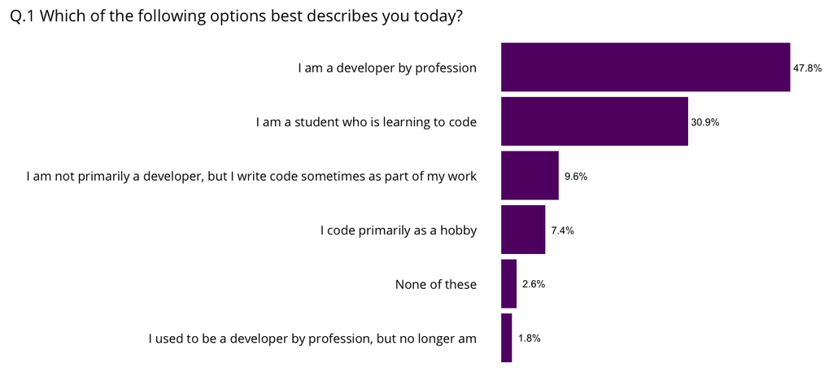

## Technology and Tech Culture

### Q7. How frequently do you learn a new language or framework?

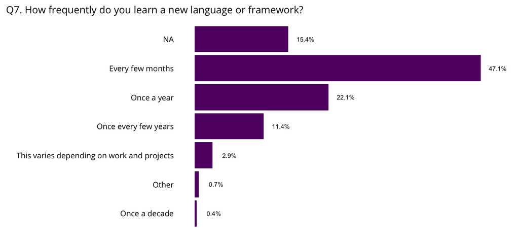

### Q14. What is the primary operating system in which you work?

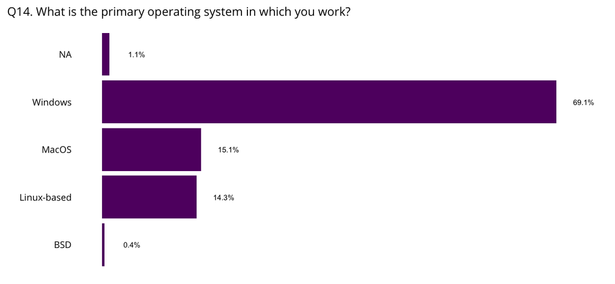

### Q15. In which operating system would you rather work?

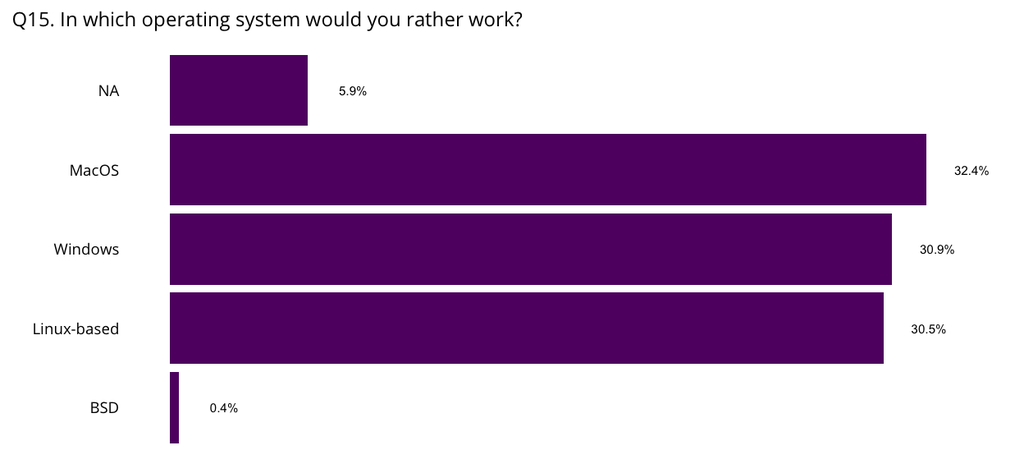

### Q16. What level of influence do you, personally, have over new technology purchases at your organization?

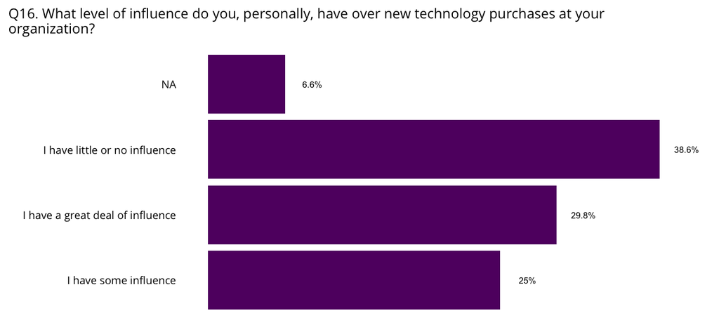

### Q17. When buying a new tool or software, how do you discover and research available solutions? Select all that apply.

[figure not shown]

## Education, Work and Career

### Q18. Which of the following best describes the highest level of formal education that you have completed?

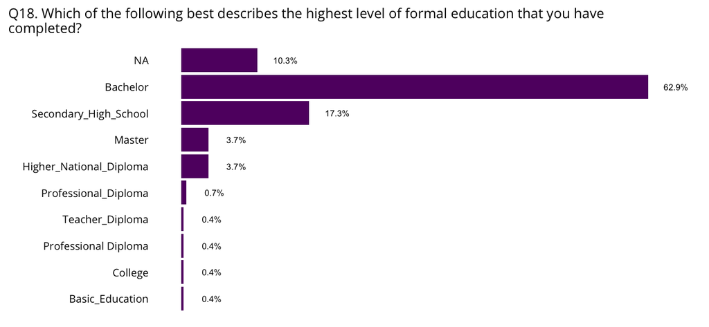

### Q19. What was your primary field of study?

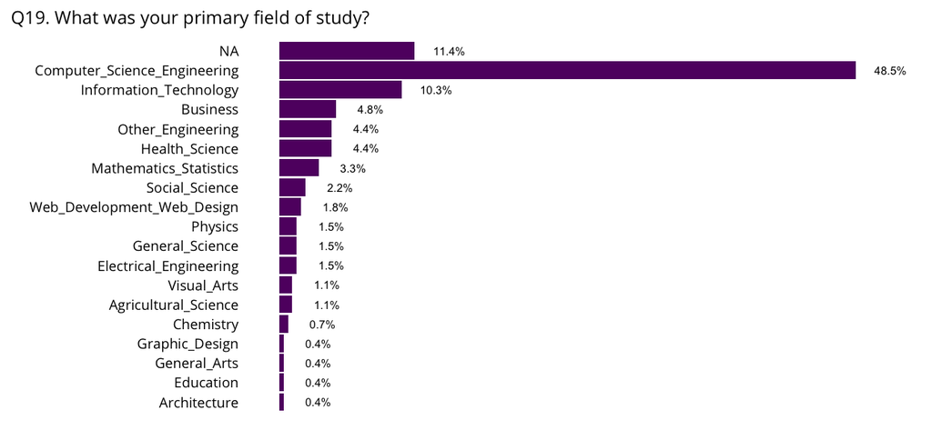

### Q20. How important is a formal education, such as a university degree in computer science, to your career?

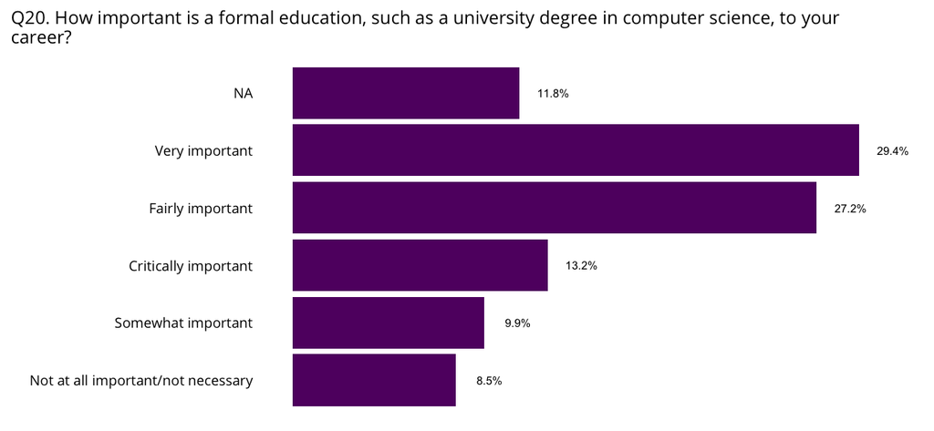

### Q21. From Q18, if you could go back and change your educational path (but end up in the same career), what would you change?

```
                                                                                                                                   change_edu_21
1                                                                                                                           Approach to learning
2                                                                                                                     Business or graphic design
3                                                                                                                               change my school
4                                                                                                 Combination of modules I select for the course
5                                                                                                                                     Curriculum
6                                                                                                                                 field of study
7                                                                                                                      How I learned programming
8                                                                                                                     How the courses are taught
9                                                                                                              I will change the course I chose.
10                                                                                                I woud have added something else to my studies
11                                                                                                                   I woud not go to university
12                                                            I would change my programme of study to computer science, or software engineering.
13                                                                                                         I would select information technology
14                                                                                                                I would study Computer Science
```

[output cut: 63 more lines]

### Q22. How satisfied are you with your current job? (If you work multiple jobs, answer for one you spend the most hours on.)

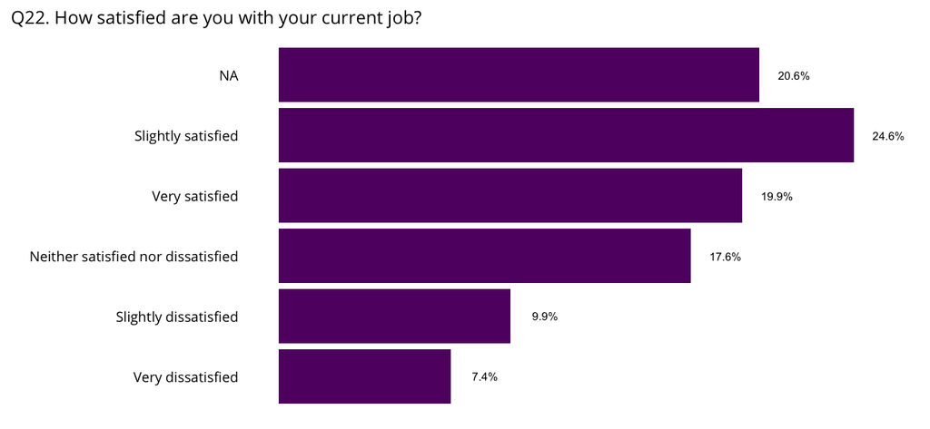

### Q23. Approximately how many people are employed by the company or organization you currently work for?

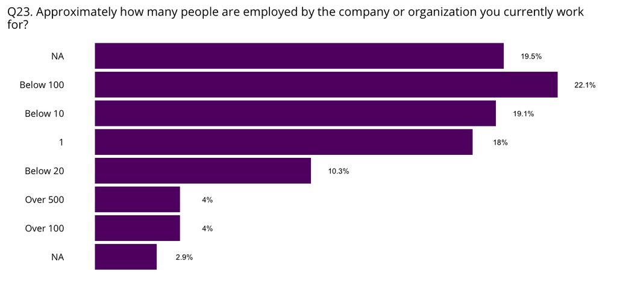

### Q24. On average, how many hours per week do you work? Please enter a whole number in the box.

```
   weekly_work_hours_24  n        perc perc_label
1                     0  2 0.007352941       0.7%
2                     2  1 0.003676471       0.4%
3                     4  4 0.014705882       1.5%
4                     5  4 0.014705882       1.5%
5                     6  7 0.025735294       2.6%
6                     7  1 0.003676471       0.4%
7                     8  6 0.022058824       2.2%
8                     9  6 0.022058824       2.2%
9                    10  4 0.014705882       1.5%
10                   12  4 0.014705882       1.5%
11                   15  1 0.003676471       0.4%
12                   19  1 0.003676471       0.4%
13                   20  6 0.022058824       2.2%
14                   21  1 0.003676471       0.4%
```

[output cut: 33 more lines]

### Q25. How often do you work overtime or beyond the formal time expectation of your job?

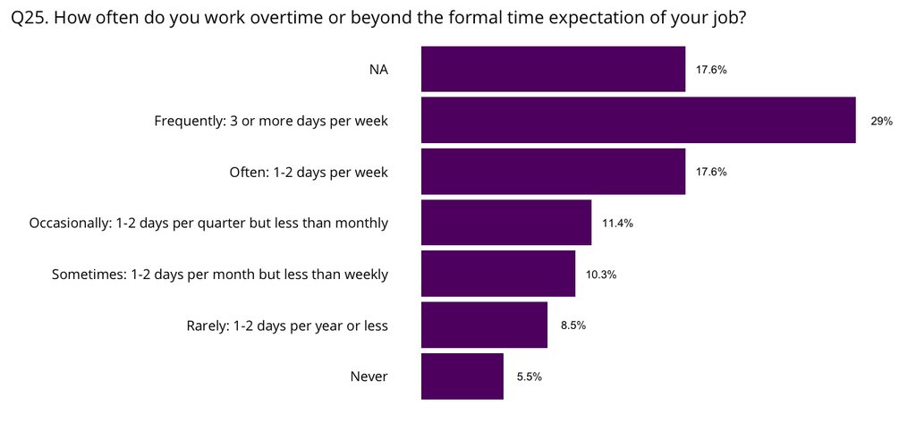

### Q26. Do you think your company has a good on-boarding process? (By on-boarding, we mean the structured process of getting you settled in to your new role at a company)

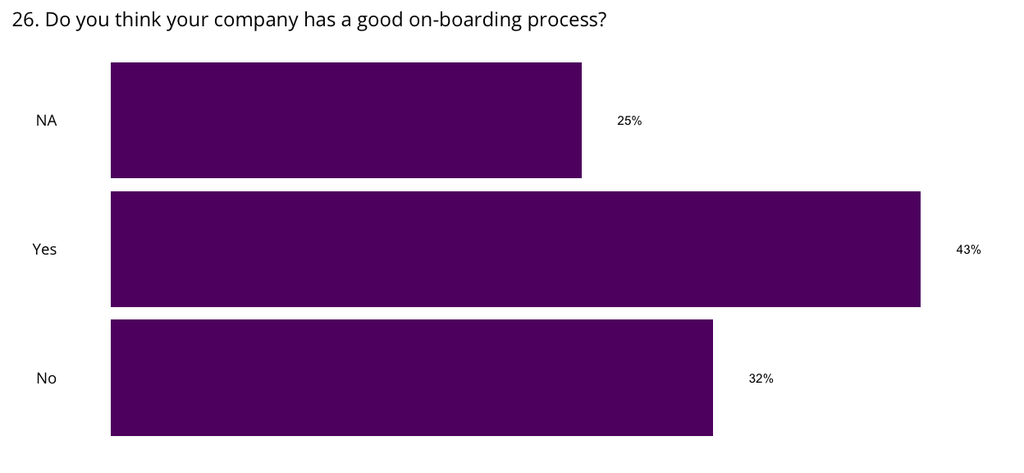

### Q27. How could on-boarding at your company be improved?

```
                                                                                                          improve_onboarding_27
1                                                                           A little interview on the chosen choice of language
2                                                                                     A standardized structure for onboard ding
3                                                                                             Adequate funds for the right role
4                                                                                    Assign mentors to newly assigned employees
5                                                                                                       Better background check
6                                                                           By applying more practical tests for the individual
7                                                       By clearly defining the core functions of the various units/departments
8                                                                                    By defining a structure in the first place
9                                                                                              By establishing an HR Department
10                                                        By improving the organisational structure to facilitate the work flow
11                                                                                                            Capacity building
12                                                                                                                Communication
13 Company needs to allow the organisational structures to work without interference and clear task to be assigned to new hires
14                                     Could have someone to take me through the code instead of having to understand it myself
```

[output cut: 119 more lines]

### Q28. How much is your monthly salary in Ghana Cedis?

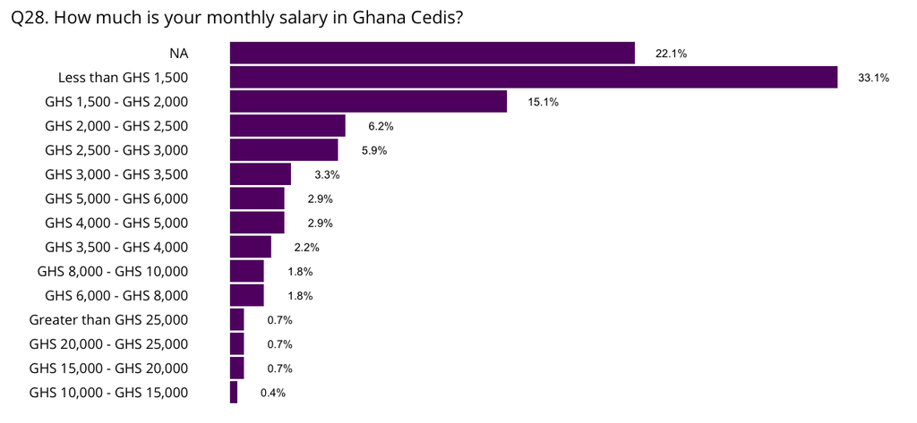

### Q29. Which of the following best describes your current job-seeking status?

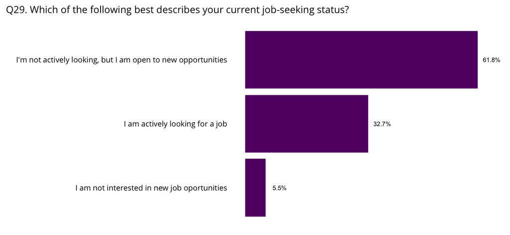

### Q30. In general, what drives you to look for a new job? Select all that apply.

[figure not shown]

### Q31. When job searching, how do you learn more about a company? Select all that apply.

[figure not shown]

### Q32. Are you a member of any other online/offline developer communities?

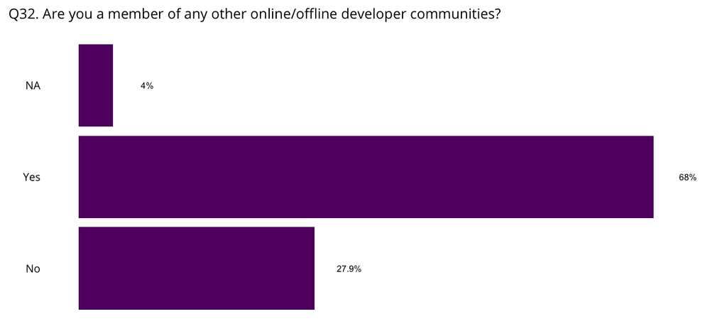

### Q33. Developer communities you are a member of

```
                                                                                                   which_dev_community_33
1                                                                                                   Accra .NET User Group
2                                                                                                   Aenics;Diversity Tech
3                                                                                               Andela Learning Community
4                                                          Andela Learning Community;DevCongress;Laravel Developers Ghana
5                       Arduino developer community;Raspberry pi developer community;Stack Exchange;Tensorflow developers
6                                                                                     AWS Accra Meetup;Hacklab Foundation
7                                                                                               Azubi Africa;Python Ghana
8                                                                                                                    Code
9                                                                                                                CodeHive
10                                                                                                               Codewars
11                                                                                                     Dev.to;DevCongress
12                                                                                               Dev.to;HackerRank;GitHub
13                                                                                                            DevCongress
14                                                          DevCongress;Developers in Vogue;Python Ghana;Women TechMakers
```

[output cut: 233 more lines]